# Exercises Chapter 12

Gerko Vink

Statistical Programming in R

1. **Carry out a principal components analysis on the possum data for the following scenarios and compare the loadings for the first and second principal components in these new analyses.**
- all possums
- only the female possums
- only the male possums

Let us do the PCA for females,

```r
require(DAAG)
females <- princomp(na.omit(possum[possum$sex=="f", -(1:5)]))
```

for males,

```r
males <- princomp(na.omit(possum[possum$sex=="m", -(1:5)]))
```

and for everyone.

```r
everyone <- princomp(na.omit(possum[, -(1:5)]))
```

Now we extract the loadings,

```r
fem<-females$loadings[,c("Comp.1", "Comp.2")]
mal<-males$loadings[,c("Comp.1", "Comp.2")]
all<-everyone$loadings[,c("Comp.1", "Comp.2")]
```

plot them,

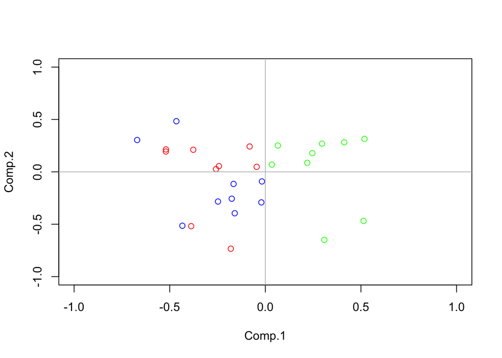

```r
plot(fem, ylim = c(-1,1), xlim=c(-1,1), col = "blue")
points(mal, col = "red")
points(all, col = "green")
abline(h = 0, col = "grey")
abline(v = 0, col = "grey")
```

and, finally, print them.

```r
cbind(fem, mal, all)
```

```
##               Comp.1      Comp.2      Comp.1      Comp.2     Comp.1
## hdlngth  -0.24764897 -0.28326791 -0.52032961  0.19397076 0.41265438
## skullw   -0.17566366 -0.25637247 -0.37694183  0.21081549 0.29632170
## totlngth -0.43381161 -0.51464727 -0.51956302  0.21393200 0.51844851
## taill    -0.02088793 -0.29167847 -0.08212305  0.24188071 0.06564697
## footlgth -0.67030090  0.30403794 -0.38781632 -0.51860524 0.51363617
## earconch -0.46515338  0.48335093 -0.18060981 -0.73398438 0.30862283
## eye      -0.01780398 -0.09158939 -0.04517671  0.04784636 0.03424285
## chest    -0.16608029 -0.11555255 -0.24269768  0.05451985 0.21928822
## belly    -0.16004011 -0.39533037 -0.25790993  0.02669897 0.24592960
##               Comp.2
## hdlngth   0.28240789
## skullw    0.26911525
## totlngth  0.31488783
## taill     0.25119168
## footlgth -0.46820125
## earconch -0.64991944
## eye       0.06974825
## chest     0.08604901
## belly     0.17802870
```

It is clear that the combined data loads differently than the seperate parts. However, if we reverse the sign of the loadings for males and females we obtain a solution that is very similar to the solution for the combined data. Moreover we then see that males and females load quite opposite from one another on Component 2.

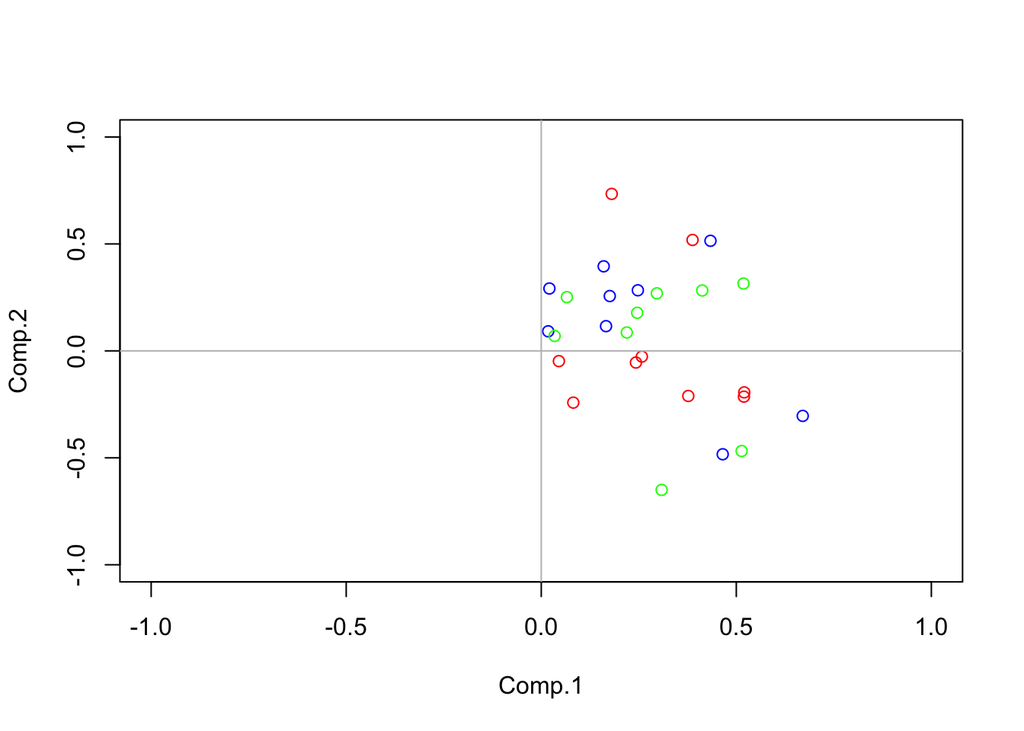

```r
plot(fem * -1, ylim = c(-1,1), xlim=c(-1,1), col = "blue")
points(mal * -1, col = "red")
points(all, col = "green")
abline(h = 0, col = "grey")
abline(v = 0, col = "grey")
```

2. **Use the funtion `PCA` on the `Decathlon` dataset from `FactoMineR` to perform a principal components analysis.**

```r
require(FactoMineR)
data(decathlon)
```

We select the 10 sporting activity variables

```r
head(decathlon)
```

```
##          100m Long.jump Shot.put High.jump  400m 110m.hurdle Discus
## SEBRLE  11.04      7.58    14.83      2.07 49.81       14.69  43.75
## CLAY    10.76      7.40    14.26      1.86 49.37       14.05  50.72
## KARPOV  11.02      7.30    14.77      2.04 48.37       14.09  48.95
## BERNARD 11.02      7.23    14.25      1.92 48.93       14.99  40.87
## YURKOV  11.34      7.09    15.19      2.10 50.42       15.31  46.26
## WARNERS 11.11      7.60    14.31      1.98 48.68       14.23  41.10
##         Pole.vault Javeline 1500m Rank Points Competition
## SEBRLE        5.02    63.19 291.7    1   8217    Decastar
## CLAY          4.92    60.15 301.5    2   8122    Decastar
## KARPOV        4.92    50.31 300.2    3   8099    Decastar
## BERNARD       5.32    62.77 280.1    4   8067    Decastar
## YURKOV        4.72    63.44 276.4    5   8036    Decastar
## WARNERS       4.92    51.77 278.1    6   8030    Decastar
```

and perform the PCA on just those 10 variables

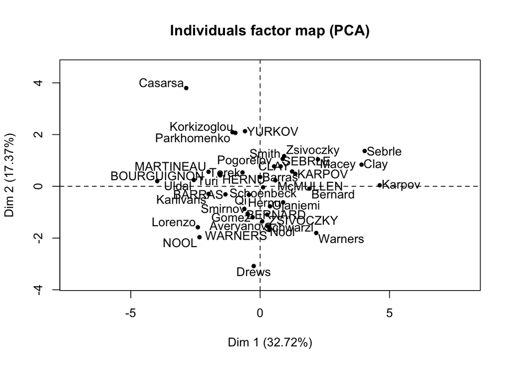

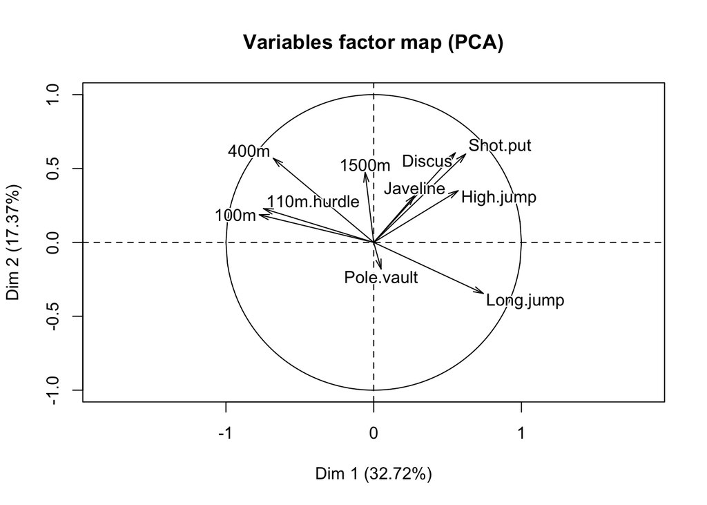

```r
pca <- PCA(decathlon[,1:10], scale.unit=TRUE, ncp=5, graph=T)
```

The first two Components account for about 50% of the variation in the variables. Based on the Eigenvalue criterion we select a 4 Components solution.

```r
pca$eig
```

```
##         eigenvalue percentage of variance
## comp 1   3.2719055              32.719055
## comp 2   1.7371310              17.371310
## comp 3   1.4049167              14.049167
## comp 4   1.0568504              10.568504
## comp 5   0.6847735               6.847735
## comp 6   0.5992687               5.992687
## comp 7   0.4512353               4.512353
## comp 8   0.3968766               3.968766
## comp 9   0.2148149               2.148149
## comp 10  0.1822275               1.822275
##         cumulative percentage of variance
## comp 1                           32.71906
## comp 2                           50.09037
## comp 3                           64.13953
## comp 4                           74.70804
## comp 5                           81.55577
## comp 6                           87.54846
## comp 7                           92.06081
## comp 8                           96.02958
## comp 9                           98.17773
## comp 10                         100.00000
```

```r
load <- sweep(pca$var$coord,2,sqrt(pca$eig[1:ncol(pca$var$coord),1]),FUN="/")[,1:4]
varimax(load)
```

```
## $loadings
##
## Loadings:
##             Dim.1  Dim.2  Dim.3  Dim.4
## 100m        -0.462
## Long.jump    0.513
## Shot.put            0.449  0.159  0.361
## High.jump           0.461 -0.128
## 400m        -0.508         0.273
## 110m.hurdle -0.435 -0.185         0.249
## Discus              0.582  0.166
## Pole.vault   0.249 -0.415  0.547  0.339
## Javeline                  -0.144  0.801
## 1500m               0.151  0.725 -0.192
##
##                Dim.1 Dim.2 Dim.3 Dim.4
## SS loadings      1.0   1.0   1.0   1.0
## Proportion Var   0.1   0.1   0.1   0.1
## Cumulative Var   0.1   0.2   0.3   0.4
##
## $rotmat
##             [,1]       [,2]        [,3]       [,4]
## [1,]  0.82108682  0.5401956 -0.02606199  0.1825539
## [2,] -0.52278689  0.7205088  0.36581944  0.2715457
## [3,]  0.22508321 -0.2261935  0.92390018 -0.2111457
## [4,]  0.04298659 -0.3713385  0.10911171  0.9210616
```

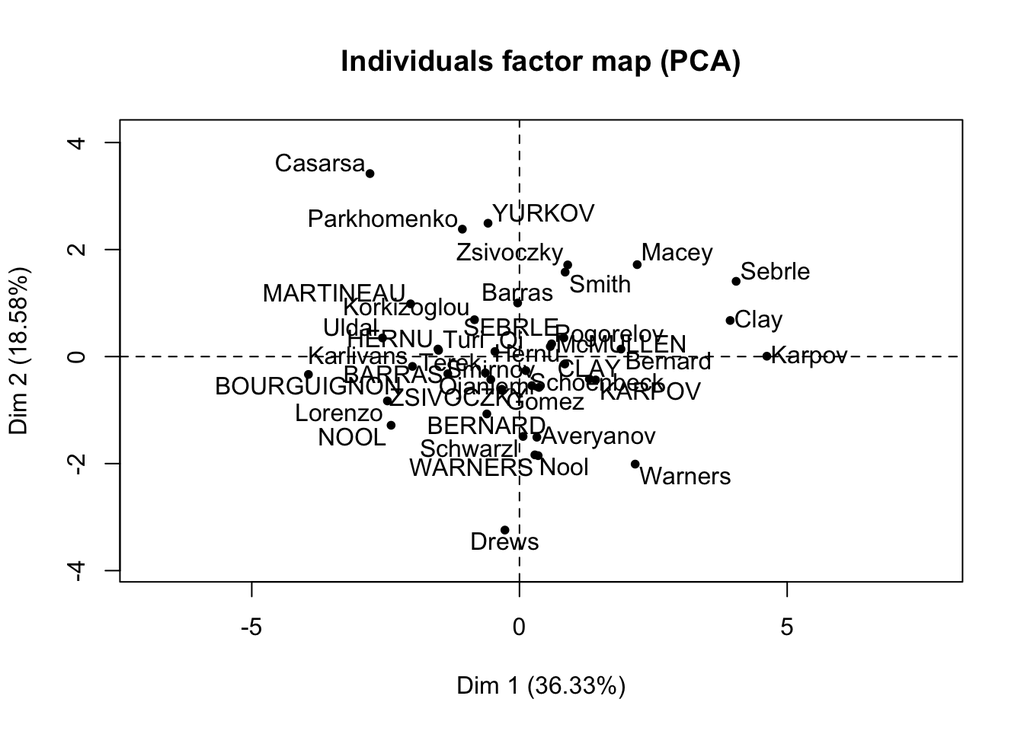

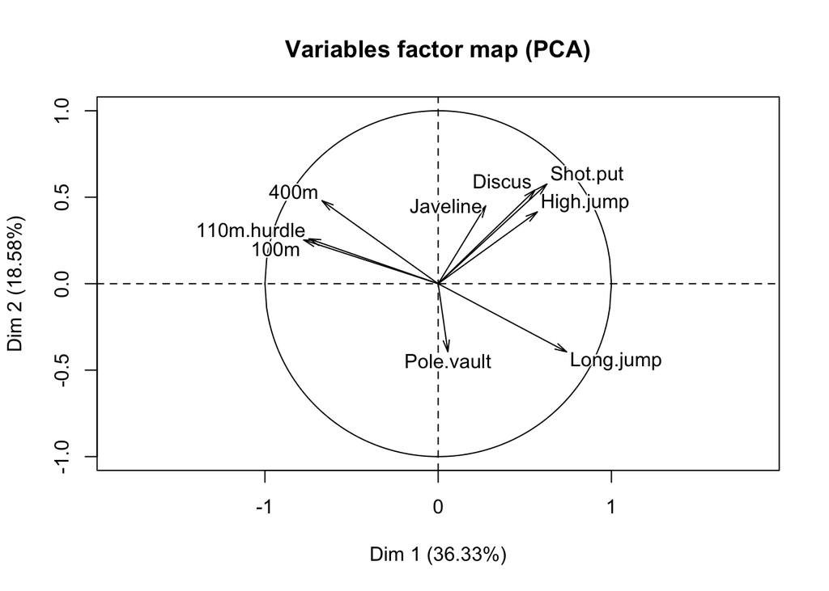

```r
pca <- PCA(decathlon[,1:9], scale.unit=TRUE, ncp=3, graph=T)
```

```r
load <- sweep(pca$var$coord,2,sqrt(pca$eig[1:ncol(pca$var$coord),1]),FUN="/")
varimax(load)
```

```
## $loadings
##
## Loadings:
##             Dim.1  Dim.2  Dim.3
## 100m        -0.461
## Long.jump    0.507         0.105
## Shot.put            0.433  0.437
## High.jump           0.476
## 400m        -0.522         0.128
## 110m.hurdle -0.460 -0.161  0.192
## Discus              0.535
## Pole.vault   0.178 -0.491  0.611
## Javeline            0.160  0.598
##
##                Dim.1 Dim.2 Dim.3
## SS loadings    1.000 1.000 1.000
## Proportion Var 0.111 0.111 0.111
## Cumulative Var 0.111 0.222 0.333
##
## $rotmat
##             [,1]       [,2]      [,3]
## [1,]  0.81070222  0.5330438 0.2421286
## [2,] -0.58452003  0.7603482 0.2832082
## [3,] -0.03313966 -0.3711265 0.9279908
```

To perform a Oblimin rotation on the factor loadings:

```r
require(GPArotation)
oblimin(load)
```

```
## Oblique rotation method Oblimin Quartimin converged.
## Loadings:
##               Dim.1     Dim.2   Dim.3
## 100m        -0.4505 -0.110028 -0.1164
## Long.jump    0.4819  0.031231  0.2079
## Shot.put     0.0127  0.614183  0.0209
## High.jump    0.1292  0.370094 -0.3011
## 400m        -0.5250  0.111641 -0.0370
## 110m.hurdle -0.4955 -0.000257  0.1562
## Discus       0.0662  0.451832 -0.3129
## Pole.vault   0.0460  0.020743  0.8021
## Javeline    -0.1466  0.509127  0.2986
##
## Rotating matrix:
##        [,1]  [,2]    [,3]
## [1,]  0.835 0.567 -0.0303
## [2,] -0.519 0.763 -0.4273
## [3,] -0.186 0.317  0.9058
##
## Phi:
##         [,1]    [,2]    [,3]
## [1,]  1.0000 -0.0196 -0.0294
## [2,] -0.0196  1.0000  0.0565
## [3,] -0.0294  0.0565  1.0000
```

If we omit the `1500m` variable (the odd one out), we obtain the following oblimin solution

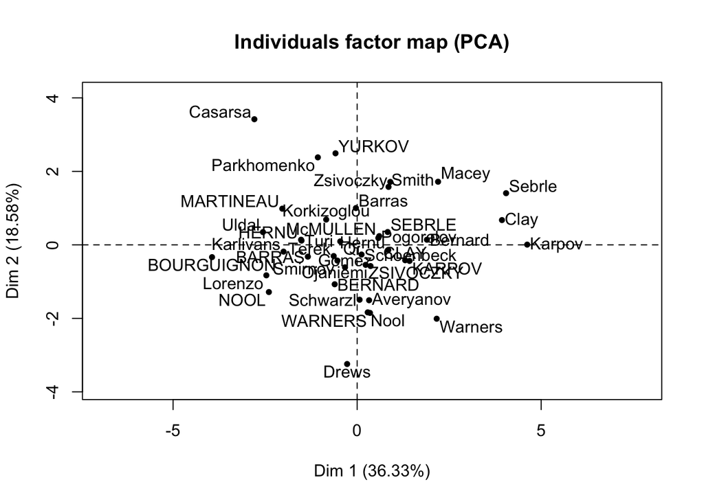

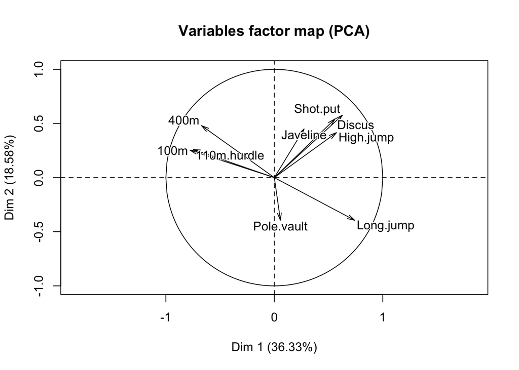

```r
pca <- PCA(decathlon[,1:9], scale.unit=TRUE, ncp=3, graph=T)
```

```r
load <- sweep(pca$var$coord,2,sqrt(pca$eig[1:ncol(pca$var$coord),1]),FUN="/")
oblimin(load)
```

```
## Oblique rotation method Oblimin Quartimin converged.
## Loadings:
##               Dim.1     Dim.2   Dim.3
## 100m        -0.4505 -0.110028 -0.1164
## Long.jump    0.4819  0.031231  0.2079
## Shot.put     0.0127  0.614183  0.0209
## High.jump    0.1292  0.370094 -0.3011
## 400m        -0.5250  0.111641 -0.0370
## 110m.hurdle -0.4955 -0.000257  0.1562
## Discus       0.0662  0.451832 -0.3129
## Pole.vault   0.0460  0.020743  0.8021
## Javeline    -0.1466  0.509127  0.2986
##
## Rotating matrix:
##        [,1]  [,2]    [,3]
## [1,]  0.835 0.567 -0.0303
## [2,] -0.519 0.763 -0.4273
## [3,] -0.186 0.317  0.9058
##
## Phi:
##         [,1]    [,2]    [,3]
## [1,]  1.0000 -0.0196 -0.0294
## [2,] -0.0196  1.0000  0.0565
## [3,] -0.0294  0.0565  1.0000
```

and we can label the components as

1. running (+ jumping far)
2. throwing
3. jumping upwards